# GROUP 7 - MACHINE LEARNING CASE STUDY

```python
import pandas as pd
import numpy as np
import matplotlib.pyplot as plt
import seaborn as sns
import warnings
warnings.filterwarnings('ignore')
sns.set_style(style="darkgrid")
```

## MERGING THE SHEETS IN EXCEL USING A PRIMARY KEY

```python
import pandas as pd
d=pd.read_excel(r"dataset.xlsx","ListOfOrders")
a=pd.read_excel(r"dataset.xlsx","OrderBreakdown")
```

```python
data=pd.merge(d,a, on='Order ID', how='outer')
```

```python
data
```

|  | Order ID | Order Date | Customer Name | City | Country | Region | Segment | Ship Date | Ship Mode | State | Product Name | Discount | Sales | Profit | Quantity | Category | Sub-Category |
| --- | --- | --- | --- | --- | --- | --- | --- | --- | --- | --- | --- | --- | --- | --- | --- | --- | --- |
| 0 | BN-2011-7407039 | 2011-01-01 | Ruby Patel | Stockholm | Sweden | North | Home Office | 2011-01-05 | Economy Plus | Stockholm | Enermax Note Cards, Premium | 0.5 | 45.0 | -26.0 | 3 | Office Supplies | Paper |
| 1 | BN-2011-7407039 | 2011-01-01 | Ruby Patel | Stockholm | Sweden | North | Home Office | 2011-01-05 | Economy Plus | Stockholm | Enermax Note Cards, Premium | 0.5 | 45.0 | -26.0 | 3 | Office Supplies | Paper |
| 2 | BN-2011-7407039 | 2011-01-01 | Ruby Patel | Stockholm | Sweden | North | Home Office | 2011-01-05 | Economy Plus | Stockholm | Enermax Note Cards, Premium | 0.5 | 45.0 | -26.0 | 3 | Office Supplies | Paper |
| 3 | BN-2011-7407039 | 2011-01-01 | Ruby Patel | Stockholm | Sweden | North | Home Office | 2011-01-05 | Economy Plus | Stockholm | Enermax Note Cards, Premium | 0.5 | 45.0 | -26.0 | 3 | Office Supplies | Paper |
| 4 | AZ-2011-9050313 | 2011-01-03 | Summer Hayward | Southport | United Kingdom | North | Consumer | 2011-01-07 | Economy | England | Dania Corner Shelving, Traditional | 0.0 | 854.0 | 290.0 | 7 | Furniture | Bookcases |
| ... | ... | ... | ... | ... | ... | ... | ... | ... | ... | ... | ... | ... | ... | ... | ... | ... | ... |
| 13126 | AZ-2014-7604524 | 2014-12-31 | Rebecca Chamberlain | Hamburg | Germany | Central | Home Office | 2015-01-04 | NaN | Hamburg | Wilson Jones Index Tab, Economy | 0.0 | 32.0 | 8.0 | 5 | Office Supplies | Binders |
| 13127 | AZ-2014-7604524 | 2014-12-31 | Rebecca Chamberlain | Hamburg | Germany | Central | Home Office | 2015-01-04 | NaN | Hamburg | Wilson Jones Index Tab, Economy | 0.0 | 32.0 | 8.0 | 5 | Office Supplies | Binders |
| 13128 | BN-2014-4140795 | 2014-12-31 | Daniel Hamilton | Eindhoven | Netherlands | Central | Home Office | 2015-01-05 | Economy Plus | North Brabant | BIC Pencil Sharpener, Fluorescent | 0.5 | 30.0 | -10.0 | 2 | Office Supplies | Art |
| 13129 | BN-2014-4140795 | 2014-12-31 | Daniel Hamilton | Eindhoven | Netherlands | Central | Home Office | 2015-01-05 | Economy Plus | North Brabant | Avery Binder Covers, Recycled | 0.5 | 23.0 | -6.0 | 4 | Office Supplies | Binders |
| 13130 | BN-2014-4140795 | 2014-12-31 | Daniel Hamilton | Eindhoven | Netherlands | Central | Home Office | 2015-01-05 | Economy Plus | North Brabant | StarTech Phone, Red | 0.5 | 108.0 | -19.0 | 3 | Technology | Machines |

13131 rows × 17 columns

### COLUMNS OF DATASET

```python
data.columns
```

```
Index(['Order ID', 'Order Date', 'Customer Name', 'City', 'Country', 'Region',
       'Segment', 'Ship Date', 'Ship Mode', 'State', 'Product Name',
       'Discount', 'Sales', 'Profit', 'Quantity', 'Category', 'Sub-Category'],
      dtype='object')
```

```python
data
```

|  | Order ID | Order Date | Customer Name | City | Country | Region | Segment | Ship Date | Ship Mode | State | Product Name | Discount | Sales | Profit | Quantity | Category | Sub-Category |
| --- | --- | --- | --- | --- | --- | --- | --- | --- | --- | --- | --- | --- | --- | --- | --- | --- | --- |
| 0 | BN-2011-7407039 | 2011-01-01 | Ruby Patel | Stockholm | Sweden | North | Home Office | 2011-01-05 | Economy Plus | Stockholm | Enermax Note Cards, Premium | 0.5 | 45.0 | -26.0 | 3 | Office Supplies | Paper |
| 1 | BN-2011-7407039 | 2011-01-01 | Ruby Patel | Stockholm | Sweden | North | Home Office | 2011-01-05 | Economy Plus | Stockholm | Enermax Note Cards, Premium | 0.5 | 45.0 | -26.0 | 3 | Office Supplies | Paper |
| 2 | BN-2011-7407039 | 2011-01-01 | Ruby Patel | Stockholm | Sweden | North | Home Office | 2011-01-05 | Economy Plus | Stockholm | Enermax Note Cards, Premium | 0.5 | 45.0 | -26.0 | 3 | Office Supplies | Paper |
| 3 | BN-2011-7407039 | 2011-01-01 | Ruby Patel | Stockholm | Sweden | North | Home Office | 2011-01-05 | Economy Plus | Stockholm | Enermax Note Cards, Premium | 0.5 | 45.0 | -26.0 | 3 | Office Supplies | Paper |
| 4 | AZ-2011-9050313 | 2011-01-03 | Summer Hayward | Southport | United Kingdom | North | Consumer | 2011-01-07 | Economy | England | Dania Corner Shelving, Traditional | 0.0 | 854.0 | 290.0 | 7 | Furniture | Bookcases |
| ... | ... | ... | ... | ... | ... | ... | ... | ... | ... | ... | ... | ... | ... | ... | ... | ... | ... |
| 13126 | AZ-2014-7604524 | 2014-12-31 | Rebecca Chamberlain | Hamburg | Germany | Central | Home Office | 2015-01-04 | NaN | Hamburg | Wilson Jones Index Tab, Economy | 0.0 | 32.0 | 8.0 | 5 | Office Supplies | Binders |
| 13127 | AZ-2014-7604524 | 2014-12-31 | Rebecca Chamberlain | Hamburg | Germany | Central | Home Office | 2015-01-04 | NaN | Hamburg | Wilson Jones Index Tab, Economy | 0.0 | 32.0 | 8.0 | 5 | Office Supplies | Binders |
| 13128 | BN-2014-4140795 | 2014-12-31 | Daniel Hamilton | Eindhoven | Netherlands | Central | Home Office | 2015-01-05 | Economy Plus | North Brabant | BIC Pencil Sharpener, Fluorescent | 0.5 | 30.0 | -10.0 | 2 | Office Supplies | Art |
| 13129 | BN-2014-4140795 | 2014-12-31 | Daniel Hamilton | Eindhoven | Netherlands | Central | Home Office | 2015-01-05 | Economy Plus | North Brabant | Avery Binder Covers, Recycled | 0.5 | 23.0 | -6.0 | 4 | Office Supplies | Binders |
| 13130 | BN-2014-4140795 | 2014-12-31 | Daniel Hamilton | Eindhoven | Netherlands | Central | Home Office | 2015-01-05 | Economy Plus | North Brabant | StarTech Phone, Red | 0.5 | 108.0 | -19.0 | 3 | Technology | Machines |

13131 rows × 17 columns

```python
data.info()
```

```
<class 'pandas.core.frame.DataFrame'>
Int64Index: 13131 entries, 0 to 13130
Data columns (total 17 columns):
 #   Column         Non-Null Count  Dtype
---  ------         --------------  -----
 0   Order ID       13131 non-null  object
 1   Order Date     13131 non-null  datetime64[ns]
 2   Customer Name  13131 non-null  object
 3   City           13131 non-null  object
 4   Country        13131 non-null  object
 5   Region         13131 non-null  object
 6   Segment        12973 non-null  object
 7   Ship Date      13131 non-null  datetime64[ns]
 8   Ship Mode      12980 non-null  object
 9   State          13131 non-null  object
 10  Product Name   13131 non-null  object
 11  Discount       13131 non-null  float64
 12  Sales          13102 non-null  float64
 13  Profit         13099 non-null  float64
 14  Quantity       13131 non-null  int64
 15  Category       13095 non-null  object
 16  Sub-Category   13131 non-null  object
dtypes: datetime64[ns](2), float64(3), int64(1), object(11)
memory usage: 1.8+ MB
```

## NUMERICAL COLUMNS:

```python
num=data.dtypes[(data.dtypes=="float64" )| (data.dtypes=="int64")].index.tolist()
print("The numerical columns are", num)
```

```
The numerical columns are ['Discount', 'Sales', 'Profit', 'Quantity']
```

## CATEGORICAL COLUMNS:

```python
cat=data.dtypes[data.dtypes=="object"].index.tolist()
print("The categoriacal columns are", cat)
```

```
The categoriacal columns are ['Order ID', 'Customer Name', 'City', 'Country', 'Region', 'Segment', 'Ship Mode', 'State', 'Product Name', 'Category', 'Sub-Category']
```

## INDEPENDENT VARIABLES

```python
Regessor=data.loc[:,['Discount','Sales','Quantity','Category','Sub-Category']]
print("Independent Variables :",Regessor.columns)
```

```
Independent Variables : Index(['Discount', 'Sales', 'Quantity', 'Category', 'Sub-Category'], dtype='object')
```

## DEPENDENT VARIABLES

```python
Target=data.loc[:,['Profit','Product Name']]
print("Dependent Variables :",Target.columns)
```

```
Dependent Variables : Index(['Profit', 'Product Name'], dtype='object')
```

```python
data.sample(10)
```

|  | Order ID | Order Date | Customer Name | City | Country | Region | Segment | Ship Date | Ship Mode | State | Product Name | Discount | Sales | Profit | Quantity | Category | Sub-Category |
| --- | --- | --- | --- | --- | --- | --- | --- | --- | --- | --- | --- | --- | --- | --- | --- | --- | --- |
| 9426 | AZ-2014-4714590 | 2014-03-08 | Chelsea Bannister | Turin | Italy | South | Consumer | 2014-03-14 | Economy | Piedmont | HP Ink, Digital | 0.0 | 385.0 | 50.0 | 3 | Technology | Copiers |
| 5550 | BN-2013-9140606 | 2013-01-16 | Maya Pamphlett | Dublin | Ireland | North | Consumer | 2013-01-21 | Economy | Dublin | Dania Corner Shelving, Metal | 0.5 | 304.0 | -18.0 | 5 | Furniture | Bookcases |
| 4707 | AZ-2012-9394311 | 2012-10-25 | Audrey Prentice | Amiens | France | Central | Home Office | 2012-10-25 | Immediate | Nord-Pas-de-Calais-Picardie | Hoover Coffee Grinder, Black | 0.1 | 184.0 | 82.0 | 3 | Office Supplies | Appliances |
| 9732 | BN-2014-7358344 | 2014-04-20 | Molly Palmer | Talence | France | Central | Corporate | 2014-04-24 | Economy | Aquitaine-Limousin-Poitou-Charentes | Belkin Memory Card, Bluetooth | 0.0 | 115.0 | 25.0 | 1 | Technology | Accessories |
| 6981 | AZ-2013-9393754 | 2013-07-22 | William Reichert | Odense | Denmark | North | Consumer | 2013-07-26 | Economy | South Denmark | Elite Trimmer, Steel | 0.5 | 103.0 | -2.0 | 5 | Office Supplies | Supplies |
| 12368 | AZ-2014-6530154 | 2014-11-19 | Bettie Lang | Lille | France | Central | Consumer | 2014-11-23 | Economy | Nord-Pas-de-Calais-Picardie | Enermax Cards & Envelopes, Premium | 0.0 | 94.0 | 27.0 | 2 | Office Supplies | Paper |
| 9655 | BN-2014-9322996 | 2014-04-12 | Louis Dominguez | Pamiers | France | Central | Corporate | 2014-04-18 | Economy | Languedoc-Roussillon-Midi-Pyrénées | Eldon Lockers, Blue | 0.1 | 1603.0 | 0.0 | 9 | Office Supplies | Storage |
| 10488 | BN-2014-5409026 | 2014-07-04 | Harry Ahmed | Gothenburg | Sweden | North | Consumer | 2014-07-09 | Economy | Västra Götaland | Stanley Sketch Pad, Easy-Erase | 0.5 | 67.0 | -42.0 | 3 | Office Supplies | Art |
| 3442 | AZ-2012-1629233 | 2012-06-20 | Mason Adams | Aubervilliers | France | Central | Consumer | 2012-06-24 | Economy | Ile-de-France | Acco Hole Reinforcements, Recycled | 0.0 | 21.0 | 11.0 | 3 | Office Supplies | Binders |
| 815 | AZ-2011-5228035 | 2011-06-15 | Kelly Long | Vienna | Austria | Central | Corporate | 2011-06-17 | Priority | Vienna | Advantus Push Pins, Assorted Sizes | 0.0 | 36.0 | 7.0 | 3 | Office Supplies | Fasteners |

## DESCRIPTION OF NUMERICAL COLUMNS

```python
data.describe()
```

|  | Discount | Sales | Profit | Quantity |
| --- | --- | --- | --- | --- |
| count | 13131.000000 | 13102.000000 | 13099.000000 | 13131.000000 |
| mean | 0.110810 | 298.025721 | 35.257653 | 3.778539 |
| std | 0.182331 | 499.312831 | 186.421072 | 2.195890 |
| min | 0.000000 | 3.000000 | -3060.000000 | 1.000000 |
| 25% | 0.000000 | 50.000000 | 1.000000 | 2.000000 |
| 50% | 0.000000 | 119.000000 | 14.000000 | 3.000000 |
| 75% | 0.100000 | 323.000000 | 48.000000 | 5.000000 |
| max | 0.850000 | 6517.000000 | 2476.000000 | 14.000000 |

## DESCRIPTION OF CATEGORICAL COLUMNS

```python
data.describe(include=['object'])
```

|  | Order ID | Customer Name | City | Country | Region | Segment | Ship Mode | State | Product Name | Category | Sub-Category |
| --- | --- | --- | --- | --- | --- | --- | --- | --- | --- | --- | --- |
| count | 13131 | 13131 | 13131 | 13131 | 13131 | 12973 | 12980 | 13131 | 13131 | 13095 | 13131 |
| unique | 4117 | 792 | 999 | 15 | 3 | 3 | 4 | 127 | 1810 | 3 | 17 |
| top | BN-2014-4964479 | Joseph Locke | London | France | Central | Consumer | Economy | England | Eldon File Cart, Single Width | Office Supplies | Art |
| freq | 39 | 58 | 388 | 3082 | 7184 | 6679 | 7885 | 1961 | 43 | 8542 | 1880 |

## HANDLING NULL VALUES

```python
data.isna().sum()
```

```
Order ID           0
Order Date         0
Customer Name      0
City               0
Country            0
Region             0
Segment          158
Ship Date          0
Ship Mode        151
State              0
Product Name       0
Discount           0
Sales             29
Profit            32
Quantity           0
Category          36
Sub-Category       0
dtype: int64
```

```python
import numpy as np
cat_unq=data["Category"].unique()
nan=cat_unq[2]
cat_unq=np.delete(cat_unq,2)
print(cat_unq)
data["Category"].fillna(999,inplace=True)

off_sup=data.loc[data['Category']==cat_unq[0],"Sub-Category"].unique()
fur=data.loc[data['Category']==cat_unq[1],"Sub-Category"].unique()
tech=data.loc[data['Category']==cat_unq[2],"Sub-Category"].unique()

for i in range(len(data)):
    for j in range(len(off_sup)):
        if data["Category"][i]==999 and data["Sub-Category"][i]==off_sup[j]:
            data["Category"][i]="Office Supplies"

for i in range(len(data)):
    for j in range(len(fur)):
        if data["Category"][i]==999 and data["Sub-Category"][i]==fur[j]:
            data["Category"][i]="Furniture"

for i in range(len(data)):
    for j in range(len(tech)):
        if data["Category"][i]==999 and data["Sub-Category"][i]==tech[j]:
            data["Category"][i]="Technology"
```

```
['Office Supplies' 'Furniture' 'Technology']
```

```python
data.isna().sum()
```

```
Order ID           0
Order Date         0
Customer Name      0
City               0
Country            0
Region             0
Segment          158
Ship Date          0
Ship Mode        151
State              0
Product Name       0
Discount           0
Sales             29
Profit            32
Quantity           0
Category           0
Sub-Category       0
dtype: int64
```

```python
import numpy as np
seg_unq=data["Segment"].unique()
seg_unq=np.delete(seg_unq,3)
print(seg_unq)
data["Segment"].fillna(999,inplace=True)
sub_unq=data["Sub-Category"].unique()
for i in range(len(sub_unq)):
    print(data.loc[data["Sub-Category"]==sub_unq[i],["Sub-Category","Segment"]].mode())
for i in range(len(data)):
    if data["Segment"][i]==999 :
        data["Segment"][i]="Consumer"
```

```
['Home Office' 'Consumer' 'Corporate']
  Sub-Category   Segment
0        Paper  Consumer
  Sub-Category   Segment
0    Bookcases  Consumer
  Sub-Category   Segment
0          Art  Consumer
  Sub-Category   Segment
0      Storage  Consumer
  Sub-Category   Segment
0    Fasteners  Consumer
  Sub-Category   Segment
0      Binders  Consumer
  Sub-Category   Segment
0       Tables  Consumer
  Sub-Category   Segment
0       Labels  Consumer
  Sub-Category   Segment
0       Chairs  Consumer
  Sub-Category   Segment
0     Machines  Consumer
  Sub-Category   Segment
0       Phones  Consumer
  Sub-Category   Segment
0   Appliances  Consumer
  Sub-Category   Segment
0     Supplies  Consumer
  Sub-Category   Segment
0      Copiers  Consumer
  Sub-Category   Segment
0    Envelopes  Consumer
  Sub-Category   Segment
0  Accessories  Consumer
  Sub-Category   Segment
0  Furnishings  Consumer
```

```python
data.isna().sum()
```

```
Order ID           0
Order Date         0
Customer Name      0
City               0
Country            0
Region             0
Segment            0
Ship Date          0
Ship Mode        151
State              0
Product Name       0
Discount           0
Sales             29
Profit            32
Quantity           0
Category           0
Sub-Category       0
dtype: int64
```

```python
data.loc[data["Segment"]==999]
```

|  | Order ID | Order Date | Customer Name | City | Country | Region | Segment | Ship Date | Ship Mode | State | Product Name | Discount | Sales | Profit | Quantity | Category | Sub-Category |
| --- | --- | --- | --- | --- | --- | --- | --- | --- | --- | --- | --- | --- | --- | --- | --- | --- | --- |

```python
import numpy as np
ship_unq=data["Ship Mode"].unique()
ship_unq=np.delete(ship_unq,3)
print(ship_unq)
data["Ship Mode"].fillna(999,inplace=True)
sub_unq=data["Sub-Category"].unique()
for i in range(len(sub_unq)):
    print(data.loc[data["Sub-Category"]==sub_unq[i],["Sub-Category","Ship Mode"]].mode())
for i in range(len(data)):
    if data["Ship Mode"][i]==999:
        data["Ship Mode"][i]="Economy"
```

```
['Economy Plus' 'Economy' 'Priority' 'Immediate']
  Sub-Category Ship Mode
0        Paper   Economy
  Sub-Category Ship Mode
0    Bookcases   Economy
  Sub-Category Ship Mode
0          Art   Economy
  Sub-Category Ship Mode
0      Storage   Economy
  Sub-Category Ship Mode
0    Fasteners   Economy
  Sub-Category Ship Mode
0      Binders   Economy
  Sub-Category Ship Mode
0       Tables   Economy
  Sub-Category Ship Mode
0       Labels   Economy
  Sub-Category Ship Mode
0       Chairs   Economy
  Sub-Category Ship Mode
0     Machines   Economy
  Sub-Category Ship Mode
0       Phones   Economy
  Sub-Category Ship Mode
0   Appliances   Economy
  Sub-Category Ship Mode
0     Supplies   Economy
  Sub-Category Ship Mode
0      Copiers   Economy
  Sub-Category Ship Mode
0    Envelopes   Economy
  Sub-Category Ship Mode
0  Accessories   Economy
  Sub-Category Ship Mode
0  Furnishings   Economy
```

```python
data.isna().sum()
```

```
Order ID          0
Order Date        0
Customer Name     0
City              0
Country           0
Region            0
Segment           0
Ship Date         0
Ship Mode         0
State             0
Product Name      0
Discount          0
Sales            29
Profit           32
Quantity          0
Category          0
Sub-Category      0
dtype: int64
```

```python
import numpy as np
profit_unq=data["Profit"].unique()
profit_unq=np.delete(profit_unq,3)
print(profit_unq)
sub_unq=data["Sub-Category"].unique()
l=[]
for i in range(len(sub_unq)):
    l.append([sub_unq[i],data.loc[data["Sub-Category"]==sub_unq[i],"Profit"].mean()])
data["Profit"].fillna("999",inplace=True)
for i in range(len(data)):
    for j in range(len(l)):
        if l[j][0]==data["Sub-Category"][i] and data["Profit"][i]=="999":
            data["Profit"][i]=l[j][1]
```

[output not shown]

[output cut: 86 more lines]

```
 -8.400e+01 -1.128e+03  2.380e+02 -9.800e+02  8.910e+02  3.740e+02
 -5.050e+02 -2.090e+02  2.940e+02  1.216e+03 -5.940e+02 -4.240e+02
  1.960e+02  1.151e+03 -1.303e+03  3.520e+02  3.190e+02 -1.864e+03
  2.180e+02  7.080e+02 -2.000e+02  3.180e+02  5.090e+02  3.400e+02
 -8.020e+02  2.920e+02  5.640e+02 -2.690e+02  6.080e+02 -2.700e+02
 -5.270e+02 -3.450e+02 -4.590e+02 -3.490e+02 -2.520e+02 -4.120e+02
 -1.010e+02 -3.140e+02 -1.170e+02  3.040e+02  7.460e+02  7.070e+02
 -6.240e+02 -2.130e+02  6.800e+02 -1.800e+02 -6.330e+02 -1.920e+02
 -3.260e+02  2.590e+02  2.480e+02  3.070e+02  3.920e+02 -3.150e+02
 -4.440e+02  1.420e+03 -7.060e+02  4.090e+02  3.550e+02  4.410e+02
 -6.580e+02  5.460e+02 -9.160e+02  1.127e+03  7.940e+02 -4.390e+02
  4.320e+02 -1.148e+03 -2.720e+02  6.650e+02  2.720e+02  2.010e+02
 -3.820e+02 -2.610e+02  5.410e+02  2.640e+02  1.050e+03 -6.870e+02
  5.470e+02 -2.390e+02 -6.400e+02  4.600e+02  7.200e+02  2.690e+02
  3.780e+02  8.430e+02 -4.430e+02 -3.920e+02  8.990e+02]
```

```python
data.isna().sum()
```

```
Order ID          0
Order Date        0
Customer Name     0
City              0
Country           0
Region            0
Segment           0
Ship Date         0
Ship Mode         0
State             0
Product Name      0
Discount          0
Sales            29
Profit            0
Quantity          0
Category          0
Sub-Category      0
dtype: int64
```

```python
import numpy as np
sales_unq=data["Sales"].unique()
sales_unq=np.delete(sales_unq,3)
print(sales_unq)
sub_unq=data["Sub-Category"].unique()
l=[]
for i in range(len(sub_unq)):
    l.append([sub_unq[i],data.loc[data["Sub-Category"]==sub_unq[i],"Sales"].mean()])
data["Sales"].fillna("999",inplace=True)
for i in range(len(data)):
    for j in range(len(l)):
        if l[j][0]==data["Sub-Category"][i] and data["Sales"][i]=="999":
            data["Sales"][i]=l[j][1]
```

```
[  45.  854.  140. ... 1582. 1461. 1104.]
```

```python
data.isna().sum()
```

```
Order ID         0
Order Date       0
Customer Name    0
City             0
Country          0
Region           0
Segment          0
Ship Date        0
Ship Mode        0
State            0
Product Name     0
Discount         0
Sales            0
Profit           0
Quantity         0
Category         0
Sub-Category     0
dtype: int64
```

## HANDLING DUPLICATE VALUES

```python
print(data.duplicated().sum())
data[data.duplicated()]
```

```
5086
```

|  | Order ID | Order Date | Customer Name | City | Country | Region | Segment | Ship Date | Ship Mode | State | Product Name | Discount | Sales | Profit | Quantity | Category | Sub-Category |
| --- | --- | --- | --- | --- | --- | --- | --- | --- | --- | --- | --- | --- | --- | --- | --- | --- | --- |
| 1 | BN-2011-7407039 | 2011-01-01 | Ruby Patel | Stockholm | Sweden | North | Home Office | 2011-01-05 | Economy Plus | Stockholm | Enermax Note Cards, Premium | 0.5 | 45.0 | -26.0 | 3 | Office Supplies | Paper |
| 2 | BN-2011-7407039 | 2011-01-01 | Ruby Patel | Stockholm | Sweden | North | Home Office | 2011-01-05 | Economy Plus | Stockholm | Enermax Note Cards, Premium | 0.5 | 45.0 | -26.0 | 3 | Office Supplies | Paper |
| 3 | BN-2011-7407039 | 2011-01-01 | Ruby Patel | Stockholm | Sweden | North | Home Office | 2011-01-05 | Economy Plus | Stockholm | Enermax Note Cards, Premium | 0.5 | 45.0 | -26.0 | 3 | Office Supplies | Paper |
| 5 | AZ-2011-9050313 | 2011-01-03 | Summer Hayward | Southport | United Kingdom | North | Consumer | 2011-01-07 | Economy | England | Dania Corner Shelving, Traditional | 0.0 | 854.0 | 290.0 | 7 | Furniture | Bookcases |
| 9 | BN-2011-2819714 | 2011-01-04 | Mary Parker | Birmingham | United Kingdom | North | Corporate | 2011-01-09 | Economy | England | Boston Markers, Easy-Erase | 0.5 | 27.0 | -22.0 | 2 | Office Supplies | Art |
| ... | ... | ... | ... | ... | ... | ... | ... | ... | ... | ... | ... | ... | ... | ... | ... | ... | ... |
| 13116 | AZ-2014-3870231 | 2014-12-30 | Thomas Thompson | Basel | Switzerland | Central | Corporate | 2015-01-02 | Economy | Basel-Stadt | Nokia Headset, with Caller ID | 0.0 | 292.0 | 35.0 | 4 | Technology | Phones |
| 13117 | AZ-2014-3870231 | 2014-12-30 | Thomas Thompson | Basel | Switzerland | Central | Corporate | 2015-01-02 | Economy | Basel-Stadt | Canon Fax and Copier, Laser | 0.0 | 1913.0 | 899.0 | 10 | Technology | Copiers |
| 13118 | AZ-2014-3870231 | 2014-12-30 | Thomas Thompson | Basel | Switzerland | Central | Corporate | 2015-01-02 | Economy | Basel-Stadt | Nokia Headset, with Caller ID | 0.0 | 292.0 | 35.0 | 4 | Technology | Phones |
| 13122 | AZ-2014-8174835 | 2014-12-31 | Eloise Sykes | Bielefeld | Germany | Central | Consumer | 2015-01-04 | Economy | North Rhine-Westphalia | Kleencut Shears, Serrated | 0.0 | 261.0 | 13.0 | 6 | Office Supplies | Supplies |
| 13127 | AZ-2014-7604524 | 2014-12-31 | Rebecca Chamberlain | Hamburg | Germany | Central | Home Office | 2015-01-04 | Economy | Hamburg | Wilson Jones Index Tab, Economy | 0.0 | 32.0 | 8.0 | 5 | Office Supplies | Binders |

5086 rows × 17 columns

```python
data.drop_duplicates(inplace=True)
data[data.duplicated()]
```

|  | Order ID | Order Date | Customer Name | City | Country | Region | Segment | Ship Date | Ship Mode | State | Product Name | Discount | Sales | Profit | Quantity | Category | Sub-Category |
| --- | --- | --- | --- | --- | --- | --- | --- | --- | --- | --- | --- | --- | --- | --- | --- | --- | --- |

## OUTLIERS

```python
import seaborn as sns
import matplotlib.pyplot as plt
def outlier(col):
    print(data[col].describe())
    sns.set(rc={'figure.figsize':(25,10)})
    sns.boxplot(x=data[col])
    plt.show()
    a=data[col].quantile(0.25)
    b=data[col].quantile(0.75)
    print(f"Q1:{a},Q3:{b}")
    iqr=b-a
    print("IQR :",iqr)
    l=a-(1.5*iqr)
    u=b+(1.5*iqr)
    print(f"RANGE IS ({l},{u})")
    tenth_percentile = np.percentile(data[col], 10)
    ninetieth_percentile = np.percentile(data[col], 90)
    for i in data.index:
        if data.loc[i,col]<=l:
            data.loc[i,col]=tenth_percentile
        elif data.loc[i,col]>u:
            data.loc[i,col]=ninetieth_percentile
    sns.boxplot(x=data[col]).set(title="after")
    plt.show()
    print(data[col].describe())
```

```python
data['Sales']=data['Sales'].astype(float)
data['Profit']=data['Profit'].astype(float)
```

```
['Discount', 'Sales', 'Profit', 'Quantity']
count    8045.000000
mean        0.110075
std         0.181787
min         0.000000
25%         0.000000
50%         0.000000
75%         0.100000
max         0.850000
Name: Discount, dtype: float64
```

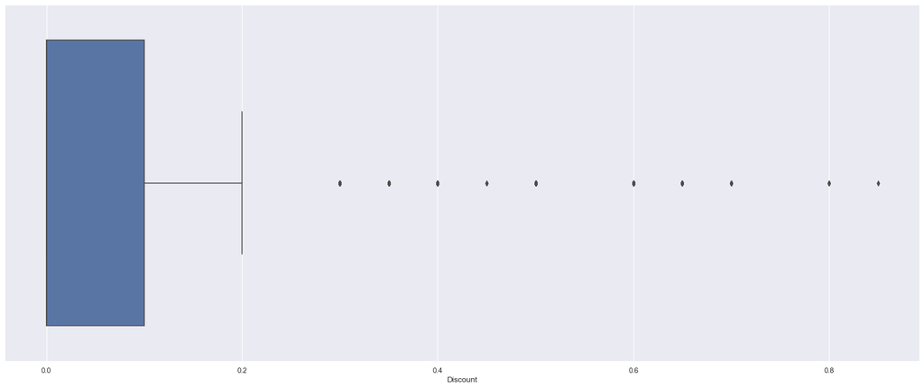

```
Q1:0.0,Q3:0.1
IQR : 0.1
RANGE IS (-0.15000000000000002,0.25)
```

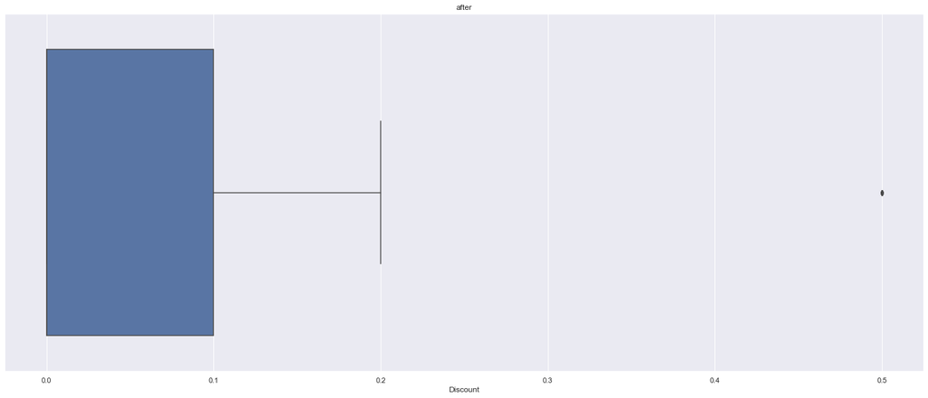

```
count    8045.000000
mean        0.113058
std         0.185795
min         0.000000
25%         0.000000
50%         0.000000
75%         0.100000
max         0.500000
Name: Discount, dtype: float64
count    8045.000000
mean      292.102223
std       485.241854
min         3.000000
25%        49.000000
50%       117.000000
75%       314.000000
max      6517.000000
Name: Sales, dtype: float64
```

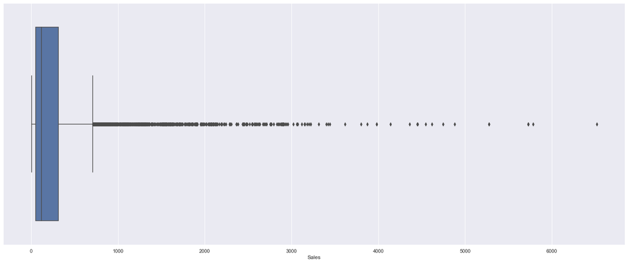

```
Q1:49.0,Q3:314.0
IQR : 265.0
RANGE IS (-348.5,711.5)
```

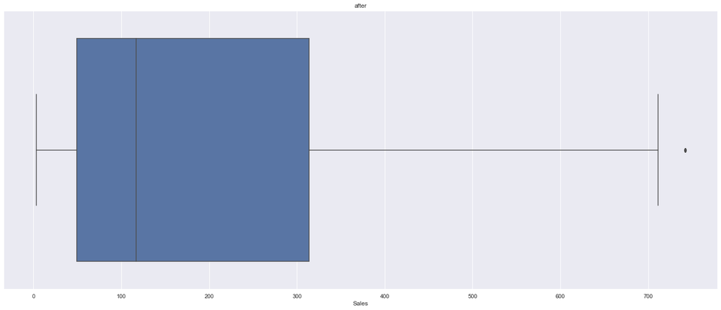

```
count    8045.000000
mean      222.364898
std       235.071929
min         3.000000
25%        49.000000
50%       117.000000
75%       314.000000
max       742.000000
Name: Sales, dtype: float64
count    8045.000000
mean       35.219716
std       178.124578
min     -3060.000000
25%         1.000000
50%        14.000000
75%        47.000000
max      2476.000000
Name: Profit, dtype: float64
```

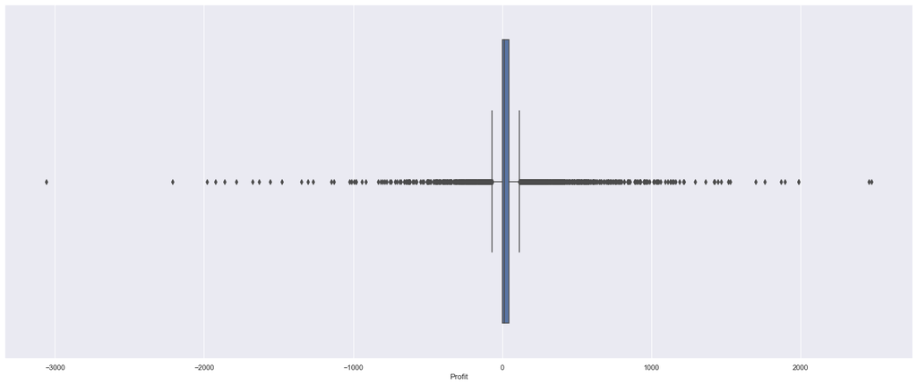

```
Q1:1.0,Q3:47.0
IQR : 46.0
RANGE IS (-68.0,116.0)
```

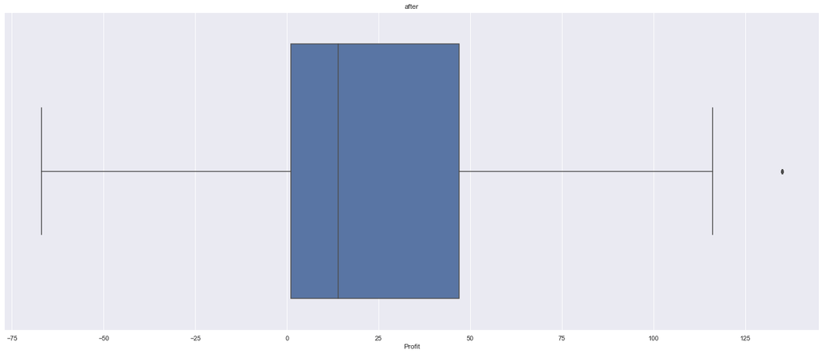

```
count    8045.000000
mean       28.544016
std        49.929569
min       -67.000000
25%         1.000000
50%        14.000000
75%        47.000000
max       135.000000
Name: Profit, dtype: float64
count    8045.000000
mean        3.772281
std         2.203610
min         1.000000
25%         2.000000
50%         3.000000
75%         5.000000
max        14.000000
Name: Quantity, dtype: float64
```

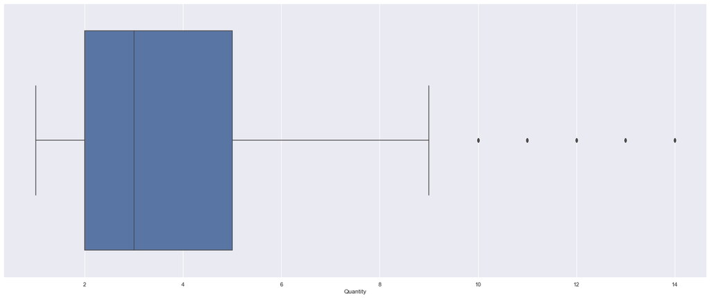

```
Q1:2.0,Q3:5.0
IQR : 3.0
RANGE IS (-2.5,9.5)
```

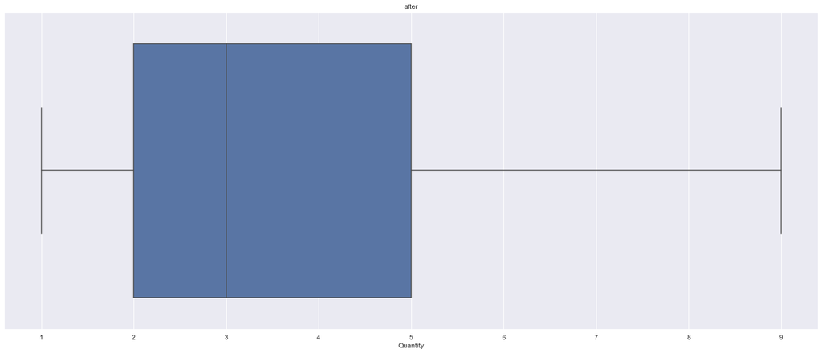

```
count    8045.000000
mean        3.688999
std         1.975606
min         1.000000
25%         2.000000
50%         3.000000
75%         5.000000
max         9.000000
Name: Quantity, dtype: float64
```

```python
num=data.dtypes[(data.dtypes=="float64" )| (data.dtypes=="int64")].index.tolist()
print(num)
for i in num:
    outlier(i)
```

```python
y=pd.DataFrame(data.loc[:,['Discount','Sales','Profit','Quantity']])
num.remove("Discount")
num.remove("Sales")
num.remove("Profit")
num.remove("Quantity")
for i in num:
    min_l=[data[i].min()]*len(data)
    max_l=[data[i].max()]*len(data)
    y[i] = (data[i] - min_l) / (data[i].max() - data[i].min())
y
```

|  | Discount | Sales | Profit | Quantity |
| --- | --- | --- | --- | --- |
| 0 | 0.5 | 45.000000 | -26.0 | 3 |
| 4 | 0.0 | 742.000000 | 135.0 | 7 |
| 6 | 0.0 | 140.000000 | 21.0 | 3 |
| 7 | 0.5 | 27.000000 | -22.0 | 2 |
| 8 | 0.5 | 17.000000 | -1.0 | 2 |
| ... | ... | ... | ... | ... |
| 13125 | 0.0 | 265.172861 | 75.0 | 5 |
| 13126 | 0.0 | 32.000000 | 8.0 | 5 |
| 13128 | 0.5 | 30.000000 | -10.0 | 2 |
| 13129 | 0.5 | 23.000000 | -6.0 | 4 |
| 13130 | 0.5 | 108.000000 | -19.0 | 3 |

8045 rows × 4 columns

## EXPLORATORY DATA ANALYSIS

### SALES PERCENTAGE FOR 3 DIFFERENT CATEGORIES

```python
data.value_counts("Category")
```

```
Category
Office Supplies    5284
Technology         1523
Furniture          1238
dtype: int64
```

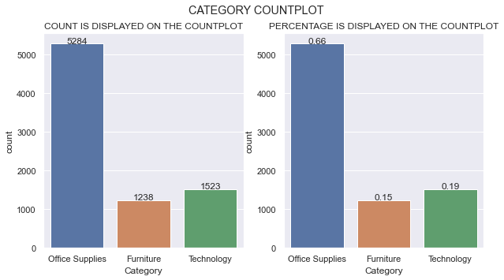

```python
fig,ax = plt.subplots(1,2, figsize=(10,5))
plt.suptitle("CATEGORY COUNTPLOT")
ax1=sns.countplot(data=data,x="Category",ax=ax[0])
ax1.set_title("COUNT IS DISPLAYED ON THE COUNTPLOT")
ax2=sns.countplot(data=data,x="Category",ax=ax[1])
ax2.set_title("PERCENTAGE IS DISPLAYED ON THE COUNTPLOT")
for i,j in zip(ax1.patches,ax2.patches):
    height = i.get_height()
    ax1.text(i.get_x()+i.get_width()/2., height + 1,height ,ha="center")
    height = j.get_height()
    ax2.text(j.get_x()+j.get_width()/2., height + 1,'{:1.2f}'.format(height/float(len(data))) ,ha="center")
```

### SALES PERCENTAGE FOR DIFFERENT SUB CATEGORIES

```python
data["Sub-Category"].value_counts()
```

```
Art            1151
Binders        1058
Storage        1051
Phones          453
Bookcases       391
Furnishings     389
Chairs          383
Paper           374
Labels          372
Accessories     368
Copiers         367
Fasteners       350
Supplies        347
Envelopes       346
Machines        335
Appliances      235
Tables           75
Name: Sub-Category, dtype: int64
```

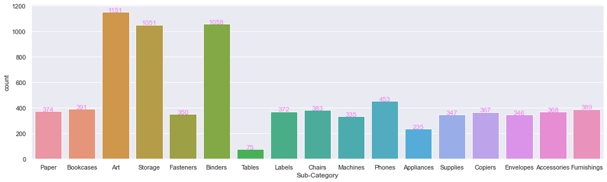

```python
fig=plt.figure(figsize=(18,5))
ax1=sns.countplot(data=data,x="Sub-Category")
for i in ax1.patches:
    height = i.get_height()
    ax1.text(i.get_x()+i.get_width()/2., height + 1,height ,ha="center",color="violet")
```

### INFERENCE: Art sub-category has higher sales and Tables sub-category has lower sales

### SALES PERCENTAGE FOR 3 DIFFERENT CATEGORIES ACCORDING TO THE SEGMENT OF CUSTOMERS

```python
data.loc[:,["Category","Segment"]].sample(10)
```

|  | Category | Segment |
| --- | --- | --- |
| 3575 | Technology | Consumer |
| 2631 | Technology | Consumer |
| 5444 | Technology | Consumer |
| 1197 | Technology | Consumer |
| 5430 | Office Supplies | Consumer |
| 5230 | Technology | Consumer |
| 13002 | Technology | Consumer |
| 3890 | Office Supplies | Home Office |
| 6515 | Office Supplies | Consumer |
| 1062 | Technology | Consumer |

```python
data["Segment"].unique()
```

```
array(['Home Office', 'Consumer', 'Corporate'], dtype=object)
```

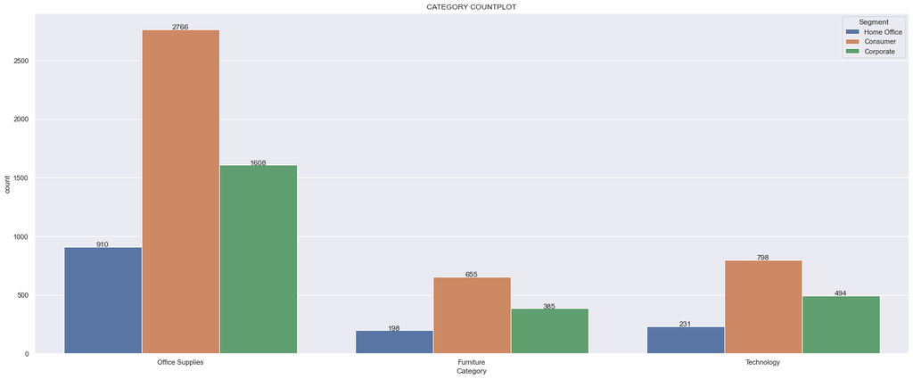

```python
plt.title("CATEGORY COUNTPLOT")
ax1=sns.countplot(data=data,x="Category",hue="Segment")
for i in ax1.patches:
    height = i.get_height()
    ax1.text(i.get_x()+i.get_width()/2., height + 1,height ,ha="center")
```

### INFERENCE: Consumer segment have purchased more products than others in all category and Home office segment have purchased less products than others in all category.

```python
d_copy=data.copy()
d_copy["month"]=pd.DatetimeIndex(data['Order Date']).month
d_copy["year"]=pd.DatetimeIndex(data['Order Date']).year
```

```python
d_copy["month"].sample(10)
```

```
7303      8
3428      6
8365     11
385       4
11239     8
199       2
46        1
9521      3
5978      3
3390      6
Name: month, dtype: int64
```

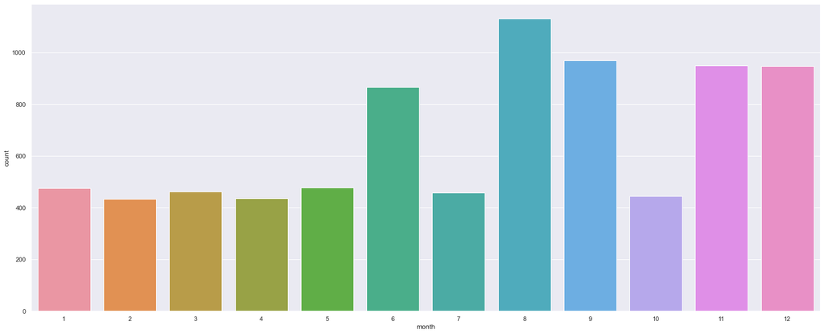

```python
sns.countplot(data=d_copy,x="month")
```

### INFERENCES: In the month of august,sales was higher and the second is September and in February the sale is down.

```python
d_copy["year"].sample(10)
```

```
12115    2014
8874     2014
10102    2014
4287     2012
12923    2014
3131     2012
7396     2013
7287     2013
8825     2013
11360    2014
Name: year, dtype: int64
```

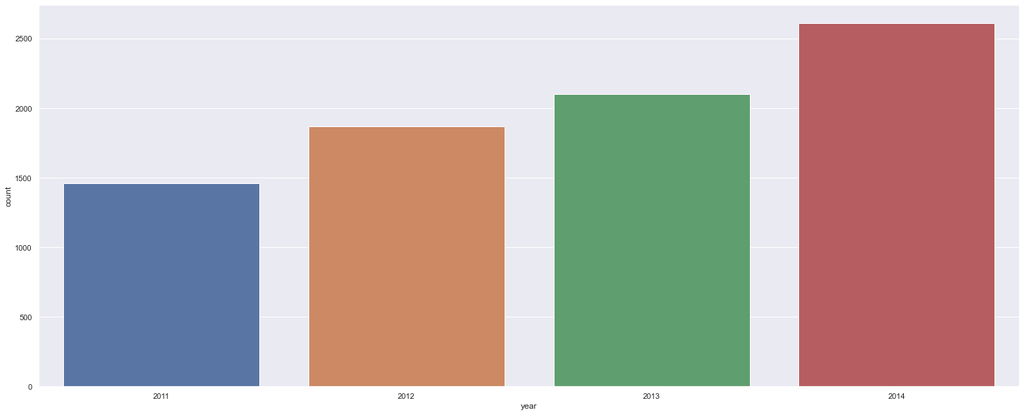

```python
sns.countplot(data=d_copy,x="year")
```

### INFERENCES: As the year passes,the sales is gradually increasing.

### SALES OF PRODUCTS FOR DIFFERENT REGIONS

```python
r=data["Region"].value_counts()
r
```

```
Central    4425
North      1811
South      1809
Name: Region, dtype: int64
```

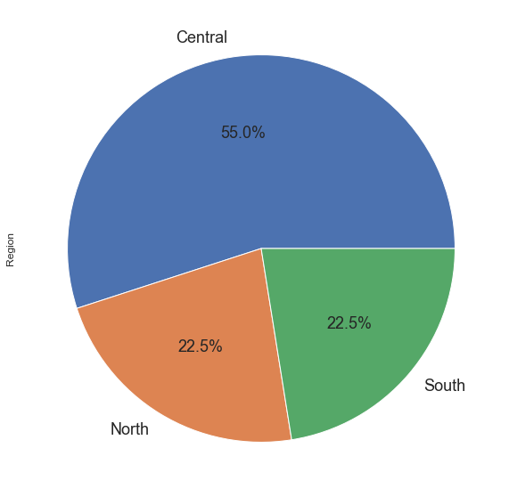

```python
r.plot.pie(autopct='%1.1f%%',figsize=(10,10),fontsize=18)
```

### INFERENCES:Many people from Central region have purchased more products than other regions and South and North region people have purchased only less products.

```python
data["Profit"].describe()
```

```
count    8045.000000
mean       28.544016
std        49.929569
min       -67.000000
25%         1.000000
50%        14.000000
75%        47.000000
max       135.000000
Name: Profit, dtype: float64
```

### DISTRIBUTION OF PROFIT

```
[(-1000.0, 1000.0)]
```

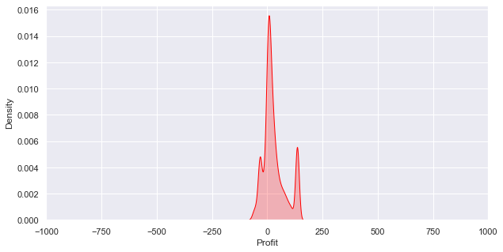

```python
fig=plt.figure(figsize=(10,5))
sns.kdeplot(data["Profit"],shade=True,color="red").set(xlim=(-1000,1000))
```

### INFERENCES:Distribution of profit is very much higher than distributribution of loss.

### PROFIT DISTRIBUTION DEPENDING ON CATEGORY

```
[(-500.0, 500.0)]
```

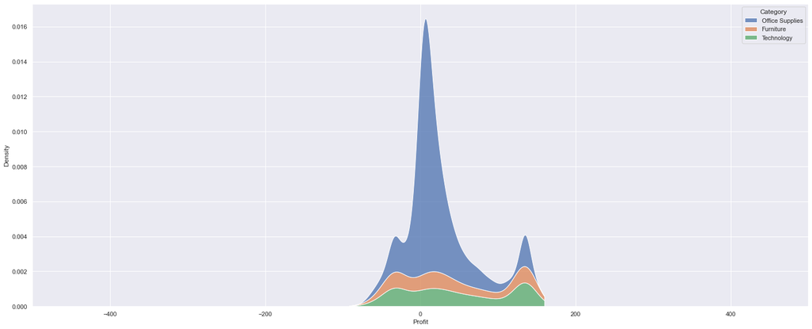

```python
sns.kdeplot(data=data, x="Profit", hue="Category", multiple="stack").set(xlim=(-500,500))
```

### INFERENCES:Probability density for profit and categorized by category attribute.From the above, we can see that office supplies has the highest profit.

### PROFIT DISTRIBUTION DEPENDING ON SUB-CATEGORY

```
[(-200.0, 200.0)]
```

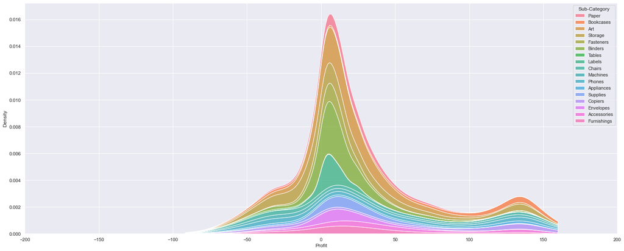

```python
sns.kdeplot(data=data, x="Profit", hue="Sub-Category", multiple="stack").set(xlim=(-200,200))
```

```python
d_copy.drop('month',axis=1,inplace=True)
```

```python
d_date=d_copy.groupby("year").mean()
```

```python
d_date.head()
```

| year | Discount | Sales | Profit | Quantity |
| --- | --- | --- | --- | --- |
| 2011 | 0.114501 | 220.268146 | 27.493093 | 3.645007 |
| 2012 | 0.102326 | 221.034571 | 29.053053 | 3.718182 |
| 2013 | 0.113381 | 221.972869 | 28.970196 | 3.686667 |
| 2014 | 0.119671 | 224.805168 | 28.425216 | 3.694604 |

### DISTRIBUTION OF PROFIT YEARWISE

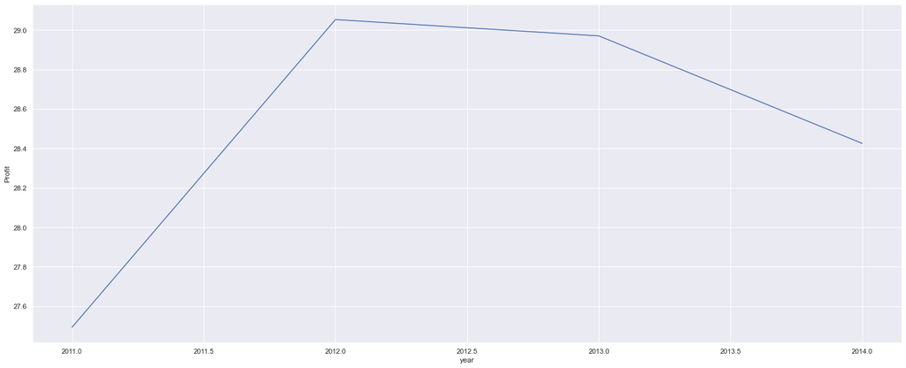

```python
sns.lineplot(data=d_date,x=d_date.index,y="Profit")
```

### INFERENCE: The profit is highest for the year 2012 and it is lowest for the year 2011.

```python
d_copy["month"]=pd.DatetimeIndex(data['Order Date']).month
d_copy.drop('year',axis=1,inplace=True)
d_date=d_copy.groupby("month").mean()
d_date.head(12)
```

| month | Discount | Sales | Profit | Quantity |
| --- | --- | --- | --- | --- |
| 1 | 0.108439 | 214.383785 | 26.396624 | 3.643460 |
| 2 | 0.113825 | 211.696780 | 25.937788 | 3.596774 |
| 3 | 0.105087 | 215.937229 | 27.220779 | 3.725108 |
| 4 | 0.115138 | 228.890604 | 29.717192 | 3.791284 |
| 5 | 0.110084 | 223.268908 | 28.278720 | 3.642857 |
| 6 | 0.112471 | 230.534727 | 30.212493 | 3.689376 |
| 7 | 0.115502 | 242.011547 | 29.846853 | 3.648472 |
| 8 | 0.111936 | 210.787723 | 27.254642 | 3.655172 |
| 9 | 0.121311 | 232.103343 | 29.958720 | 3.739938 |
| 10 | 0.093131 | 220.324324 | 32.664414 | 3.581081 |
| 11 | 0.113066 | 219.919225 | 26.794895 | 3.786091 |
| 12 | 0.121036 | 221.221169 | 28.809738 | 3.673362 |

### DISTRIBUTION OF PROFIT MONTH WISE

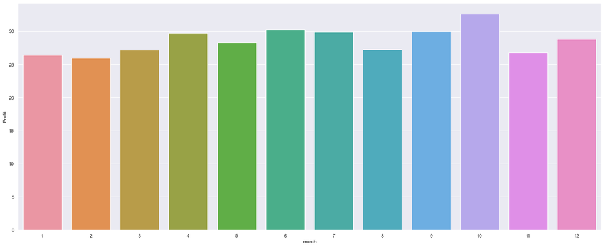

```python
sns.barplot(data=d_date,x=d_date.index,y="Profit")
```

### INFERENCE: The profit is higher at the month of October and lowest at the month of February.

### SALES OF CATEGORY DEPENDING ON SUB- CATEGORY

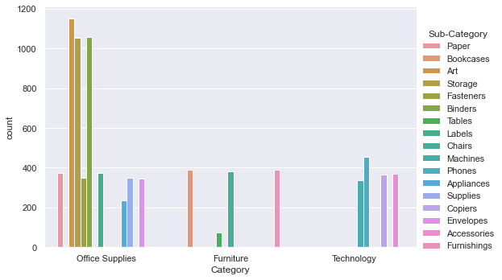

```python
sns.catplot(x='Category',hue="Sub-Category",data=data,kind = "count",aspect=1.5)
```

### INFERENCE : Sub Categories of Office supplies are purchased more and Sub Categories of Furniture and Technology are purchased in lower rate.

### SALES OF CATEGORY DEPENDING ON REGION

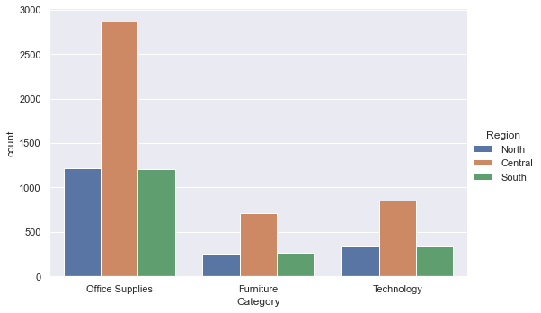

```python
sns.catplot(x='Category',hue="Region",data=data,kind = "count",aspect=1.5)
```

### INFERENCE: Office supplies are purchased more than furniture and technology category. Central region has more sales in all categories.

### REGRESSION PLOT FOR SALES AND PROFIT

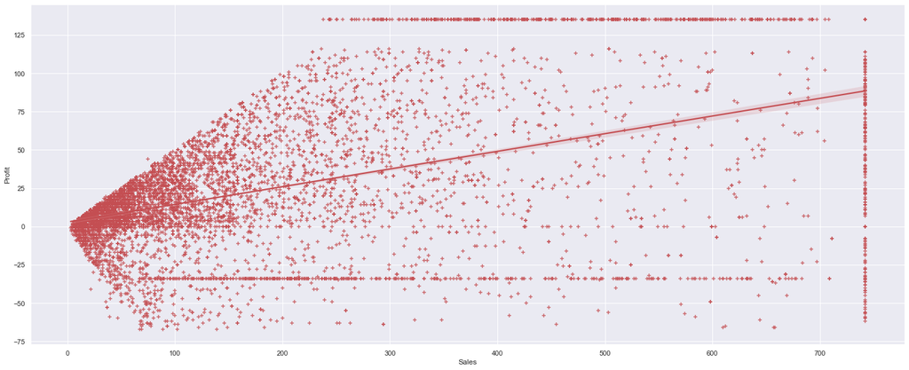

```python
sns.regplot(data["Sales"],data["Profit"],marker="+",color='r')
```

### INFERENCES: The best fit line for the attributes sales and profit.

### SALES OF DIFFERENT CATEGORIES AND SEGMENTS DEPENDING ON SUB-CATEGORY

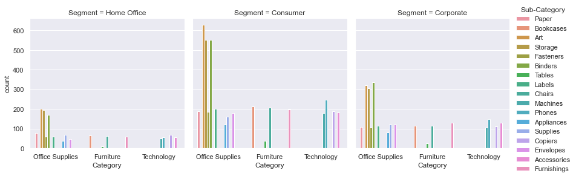

```python
sns.catplot(data=data,x="Category",col="Segment",hue="Sub-Category",kind="count",height=4,aspect=1)
```

### INFERENCE:Consumer segment has purchased more in all categories than the other segments.In each segment, Office Supplies are purchsed by many customers

### CORRELATION MATRIX

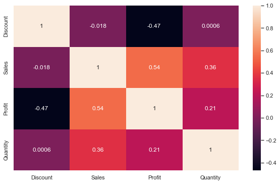

```python
fig,ax = plt.subplots(figsize = (10,6))
corr=data.corr()
sns.heatmap(corr,annot=True)
```

### ENCODING OF CATEGORICAL VARIABLES

```python
from sklearn.preprocessing import LabelEncoder
le = LabelEncoder()
for i in data.columns:
    data[i] = le.fit_transform(data[i])
data
```

|  | Order ID | Order Date | Customer Name | City | Country | Region | Segment | Ship Date | Ship Mode | State | Product Name | Discount | Sales | Profit | Quantity | Category | Sub-Category |
| --- | --- | --- | --- | --- | --- | --- | --- | --- | --- | --- | --- | --- | --- | --- | --- | --- | --- |
| 0 | 3344 | 0 | 677 | 847 | 12 | 1 | 2 | 0 | 1 | 103 | 670 | 4 | 43 | 41 | 2 | 1 | 12 |
| 4 | 510 | 1 | 724 | 841 | 14 | 1 | 0 | 1 | 0 | 41 | 513 | 0 | 665 | 194 | 6 | 0 | 4 |
| 6 | 349 | 2 | 177 | 909 | 4 | 0 | 0 | 2 | 0 | 7 | 294 | 0 | 141 | 93 | 2 | 1 | 2 |
| 7 | 3249 | 2 | 540 | 109 | 14 | 1 | 1 | 3 | 0 | 41 | 306 | 4 | 24 | 45 | 1 | 1 | 2 |
| 8 | 3249 | 2 | 540 | 109 | 14 | 1 | 1 | 3 | 0 | 41 | 585 | 4 | 14 | 66 | 1 | 1 | 14 |
| ... | ... | ... | ... | ... | ... | ... | ... | ... | ... | ... | ... | ... | ... | ... | ... | ... | ... |
| 13125 | 2241 | 1213 | 468 | 988 | 14 | 1 | 0 | 1306 | 3 | 41 | 720 | 0 | 267 | 151 | 4 | 1 | 14 |
| 13126 | 2936 | 1213 | 647 | 402 | 5 | 0 | 2 | 1309 | 0 | 54 | 1785 | 0 | 29 | 76 | 4 | 1 | 3 |
| 13128 | 3926 | 1213 | 156 | 287 | 8 | 0 | 2 | 1310 | 1 | 79 | 216 | 4 | 27 | 57 | 1 | 1 | 2 |
| 13129 | 3926 | 1213 | 156 | 287 | 8 | 0 | 2 | 1310 | 1 | 79 | 162 | 4 | 20 | 61 | 3 | 1 | 3 |
| 13130 | 3926 | 1213 | 156 | 287 | 8 | 0 | 2 | 1310 | 1 | 79 | 1666 | 4 | 107 | 48 | 2 | 2 | 11 |

8045 rows × 17 columns